# Probabilistic Learning - Classification using Naive Bayes

Kevin D’Elia

April 29th, 2017

# 1 Understanding Naive Bayes

Thomas Bayes developed foundational principles to describe the probability of events, and how probabilities should be revised in the light of additional information. These principles formed the foundation for what are now known as **Bayesian methods**.

Classifiers based on Bayesian methods utilize training data to calculate an observed probability of each outcome based on the evidence provided by feature values. When the classifier is later applied to unlabeled data, it uses the observed probabilities to predict the most likely class for the new features.

Bayesian classifiers are useful for:

- Text classification, such as junk e-mail (spam) filtering
- Intrusion or anomaly detection in computer networks
- Diagnosing medical conditions given a set of observed symptoms

Typically, Bayesian classifiers are best applied to problems in which the information from numerous attributes should be considered simultaneously in order to estimate the overall probability of an outcome. While many machine learning algorithms ignore features that have weak effects, Bayesian methods utilize all the available evidence to subtly change the predictions. If large number of features have relatively minor effects, taken together, their combine impact could be quite large.

## 1.1 Basic concepts of Bayesian methods

Bayesian probability theory is rooted in the idea that the estimated likelihood of an **event**, or a potential outcome, should be based on the evidence at hand across multiple **trials**, or opportunities for the event to occur.

[output not shown]

The probability of an event is estimated from the observed data by dividing the number of trials in which the event occurred by the total number of trials. To denote these probabilities, we use notation in the form *P(A)* which signifies the probability of event *A*.

The probability of all the possible outcomes of a trial must always sum to 1, because a trial always results in some outcome happening. Thus, if the trial has two outcomes that cannot occur simultaneously, such as rainy versus sunny or spam versus ham, then knowing the probability of either outcome reveals the probability of the other. For example, given the value *P(spam) = 0.20*, then *P(ham) = 1 - 0.20 = 0.80*. This concludes that spam and ham are **mutually exclusive and exhaustive** events, which implies that they cannot occur at the same time and are the only possible outcomes.

Because an event cannot simultaneously happen and not happen, an event is always mutually exclusive and exhaustive with its **complement**, or the event comprising of the outcomes in which the event of interest does not happen. The complement of event *A* is typically denoted *A<sup>c</sup>* or *A<sup>’</sup>*. Additionally, the shorthand notation *P(A<sup>c</sup>)* denotes the probability of event *A* not occurring.

## 1.2 Understanding joint probability

Often, we are interested in monitoring several non-mutually exclusive events for the same trial. If certain events occur with the event of interest, we may be able to use them to make predictions. Consider, for instance, a second event based on the outcome that an e-mail message contains a particular word that would most likely appear only in a spam message; its presence in an incoming e-mail is therefore a very strong piece of evidence that the message is spam. If it is known that 20% of all messages were spam and 5% of all messages contained the word in question, the goal is to estimate the probability that both *P(spam)* and *P(word)* occur; this is written as *P(spam $\cap$word)*. This notation signifies the **intersection** of the two events, or to the event where **both** *A* and *B* occur.

Calculating *P(spam $\cap$word)* depends on the **joint probability** of the two events or how the probability of one event is related to the probability of the other. If the two events are totally unrelated, the are called **independent events**. This is not to say that independent events cannot occur at the same time; event independence simply implies that knowing the outcome of one event does not provide any information about the outcome of the other. For instance, the outcome of a heads result on a coin flip is independent from whether the weather is rainy or sunny on any given day.

If all events were independent, it would be impossible to predict one event by observing another. In other words, **dependent events** are the basis of predictive modeling. Calculating the probability of dependent events is a bit more complex than for independent events. If *P(spam)* and *P(word)* were independent, calculating *P(spam $\cap$word)*, the probability of both events happening at the same time, is easy. It is simply *0.05 * 0.20 = 0.01*. More generally, for independent events *A* and *B*, the probability of both happening can be expressed as *P(spam $\cap$word) = P(A) * P(B)*. But it is more likely that the two probabilities are highly dependent, which requires a more careful formulation of the relationship between the two events based on advanced Bayesian methods.

## 1.3 Computing conditional probability with Bayes’ theorem

**Bayes’ theorem**: describes the relationship between dependent events; a way of thinking about how to revise an estimate of the probability of one event in light of the evidence provided by another event:

*P(A $\mid$ B) = $\frac{P(A \cap B)}{P(B)}$*

The notation *P(A $\mid$ B)* is read as the probability of event *A*, given that event *B* occurred. This is known as **conditional probability**, since the probability of *A* is dependent (that is, conditional) on what happened with event *B*. Bayes’ theorem tells us that our estimate of *P(A $\mid$ B)* should be based on *P(A $\cap$ B)*, a measure of how often *A* and *B* are observed to occur together, and *P(B)*, a measure of how often *B* is observed to occur in general.

Bayes’ theorem states that the best estimate of *P(A $\mid$ B)* is the proportion of trials in which *A* occurred with *B* out of all the trials in which *B* occurred. In plain language, this means that if there is knowledge that event *B* occurred, the probability of event *A* is higher the more often that *A* and *B* occur together each time *B* is observed. In a way, this adjusts *P(A $\cap$ B)* for the probability of *B* occurring; if *B* is extremely rate, *P(B)* and *P(A $\cap$ B)* will always be small; however, if *A* and *B* almost always happen together, *P(A $\mid$ B)* will be high regardless of the probability of *B*.

By definition, *P(A $\cap$ B) = P(A $\mid$ B) $\times$ P(B)* by algebra; rearrange according to *P(A $\cap$ B) = P(B $\cap$ A)* with resulting conclusion that *P(A $\cap$ B) = P(B $\mid$ A) $\times$ P(A)* (swapping B’s and A’s). This leads to:

*P(A $\mid$ B) = $\frac{P(A \cap B)}{P(B)}$ = $\frac{P(B \mid A) \times P(A)}{P(B)}$*

Continuing with the example, the best estimate of *P(spam)* was 20%; this is known as the **prior probability**. Looking more carefully at the set of previously received messages to examine the frequency of the term in question results in the probability that this word was used in previous spam messages, or *P(word $\mid$ spam)*, is called the **likelihood**. The probability that the word appeared in any message at all, or *P(word)*, is known as the **marginal likelihood**.

By applying Bayes’ theorem to this evidence, we can compute a **posterior probability** that measures how likely the message is to be spam. If the posterior probability is greater than 50%, the message is more likely to be spam. The following lists shows how the definitions given map to the components of the Bayes’ theorem:

*P(A $\mid$ B) = $\frac{P(B \mid A) \times P(A)}{P(B)}$*

**posterior probability** = *P(A $\mid$ B)*

**likelihood** = *P(B $\mid$ A)*

**prior probability** = *P(A)*

**marginal likelihood** = *P(B)*

To calculate these components of Bayes’ theorem, it helps to construct a **frequency table** that records the number of times the word appeared in spam and ham messages. Just like a two-way cross-tabulation, one dimension of the table indicates levels of the class variable (spam or ham), while the other dimension indicates levels for features (word: yes or no). The cells then indicate the number of instances having the particular combination of class value and feature value. The frequency table can then be used to construct a **likelihood table**. The rows of the likelihood table indicate the conditional probabilities for the word (yes/no), given that an e-mail was ham or spam.

# 2 The Naive Bayes algorithm

This algorithm describes a simple method to apply Bayes’ theorem to classification problems; it is the most common of the machine learning methods to do so, especially in the area of text classification. The algorithm is so named because it makes some “naive” assumptions about the data, namely, that all of the features in the dataset are equally important and independent - these assumptions are rarely true in most real-world applications.

For example, if you were attempting to identify spam by monitoring e-mail messages, it is almost certainly true that some features will be more important than others. For example, the -email sender may be a more important indicator of spam than the message text. Additionally, the words in the message body are not independent from one another, since the appearance of some words is a very good indication that other words are also likely to appear. A message with the word *Ritalin* will probably also contain the words *prescription* or *drugs*.

## 2.1 Classification with Naive Bayes

By adding terms, a larger likelihood table can be constructed. Assume four words: W<sub>1</sub>, W<sub>2</sub>, W<sub>3</sub>, and W<sub>4</sub>. As new messages arrive, a calculation of the posterior probability will determine if they are more likely to be spam or ham, given the likelihood of the words found in the message text. For example, assume that a message contains W<sub>1</sub> and W<sub>4</sub> but neither W<sub>2</sub> or W<sub>3</sub>. Using Bayes’ theorem, the following formula defines the problem:

*P(spam $\mid$ W<sub>1</sub> $\cap \neg$ W<sub>2</sub> $\cap \neg$ W<sub>3</sub> $\cap$ W<sub>4</sub>) = $\frac{P(W_1 \cap \neg W_2 \cap \neg W_3 \cap W_4 \mid spam) \times P(spam)}{P(W_1 \cap \neg W_2 \cap \neg W_3 \cap W_4)}$*

As this does not scale well computationally, a work-around uses the fact that Naive Bayes assumes independence among events, specifically, **class-conditional independence**, which means that events are independent so long as they are conditioned on the same class value (in this case, *spam* or *ham*). This allows the formula to be simplified using the probability rule for independent events, which states that *P(A $\cap$ B) = P(A) $\times$ P(B)*. Because the denominator does not depend on the class (spam or ham), it is treated as a constant value and can be ignored for the time being. This means that the conditional probability of spam can be expressed as:

**P(spam $\mid$ W<sub>1</sub> $\cap \neg$ W<sub>2</sub> $\cap \neg$ W<sub>3</sub> $\cap$ W<sub>4</sub>) $\propto$ P(W<sub>1</sub> $\mid$ spam)P($\neg$ W<sub>2</sub> $\mid$ spam)P($\neg$ W<sub>3</sub> $\mid$ spam)P(W<sub>4</sub> $\mid$ spam)P(spam)**

And the probability that the message is ham can be expressed as:

**P(ham $\mid$ W<sub>1</sub> $\cap \neg$ W<sub>2</sub> $\cap \neg$ W<sub>3</sub> $\cap$ W<sub>4</sub>) $\propto$ P(W<sub>1</sub> $\mid$ ham)P($\neg$ W<sub>2</sub> $\mid$ ham)P($\neg$ W<sub>3</sub> $\mid$ ham)P(W<sub>4</sub> $\mid$ ham)P(ham)**

Note that the equals symbol has been replaced by the proportional-to symbol to indicate the fact that the denominator has been omitted.

Using some pre-canned data, the overall likelihood of spam = 0.012 while the overall likelihood of ham = 0.002. Because the division of spam/ham = 6, this particular message is 6 times more likely to be spam than ham. However, to convert these numbers into probabilities, one last step must be performed to reintroduce the denominator that had been excluded. Essentially, the likelihood of each outcome must be re-scaled by dividing it by the total likelihood across all possible outcomes.

In this way, the probability of spam is equal to the likelihood that the message is spam divided by the likelihood that the message is either spam or ham; the resulting value is 85.7%; if this is P(spam), then by mutual exclusivity, p(ham) = 1 = P(spam), or 14.3%.

The Naive Bayes classification algorithm used in the preceding example can be summarized by the following formula. The probability of level *L* for class *C*, given the evidence provided by features *F<sub>1</sub>* through *F<sub>n</sub>*, is equal to the product of the probabilities of each piece of evidence conditioned on the class level, the prior probability of the class level, and a scaling factor *$\frac{1}{Z}$*, which converts the likelihood values into probabilities:

*P(C<sub>L</sub> $\mid$ F<sub>1</sub>, $\ldots$, F<sub>n</sub>) = $\frac{1}{Z}$ p(C<sub>L</sub>) $\prod_{i=1}^{n}$ p(F<sub>i</sub> $\mid$ C<sub>L</sub>)*

Although this equation seems intimidating, as the prior example illustrated, the series of steps is fairly straightforward. Begin by building a frequency table, use this to build a likelihood table, and multiply the conditional probabilities according to the Naive Bayes’ rule. Finally, divide by the total likelihood to transform each class likelihood into a probability.

## 2.2 The Laplace estimator

Before Naive Bayes can be used for more complex problems, there are some nuances to consider. Suppose a message contained all four terms. The likelihood for spam would be 0, making any spam calculations resolve to 0 and ham would then be 1 - p(spam) = 1, a non-nonsensical prediction. The problem might arise if an event never occurs for one or more levels of the class. For instance, the term *Groceries* had never previously appeared in a spam message. Consequently, *P(spam $\mid$ Groceries) = 0%*.

Because probabilities in the Naive Bayes formula are multiplied in a chain, this 0% value causes the posterior probability of spam to be 0, giving the word *Groceries* the ability to effectively nullify and overrule all of the other evidence. Even if the e-mail was otherwise overwhelmingly expected to be spam, the absence of the word *Groceries* in spam will always veto the other evidence and result in the probability of spam being zero.

A solution to this problem involves using something called the **Laplace estimator**, which essentially adds a small number to each of the counts in the frequency table, which ensures that each feature has a nonzero probability of occurring with each class. Typically, the Laplace estimator is set to 1, which ensures that each class-feature combination is found in the data at least once.

## 2.3 Using numeric features with Naive Bayes

Because Naive Bayes uses frequency tables to learn the data, each feature must be categorical in order to create the combinations of class and feature values comprising of the matrix. Since numeric features do not have categories of values, the preceding algorithm does not work directly with numeric data.

One easy and effective solution is to **discretize** numeric features, which simply means that the numbers are put into categories known as **bins**. For this reason, discretization is also sometimes called **binning**. This method is ideal when there are large amounts of training data, a common condition while working with Naive Bayes.

There are several different ways to discretize a numeric feature. Perhaps the most common is to explore the data for natural categories or **cut points** in the distribution of data. For example, suppose a feature was added to the spam dataset that recorded the time of night or day the e-mail was sent, from 0 to 24 hours past midnight. The data can then be plotted using a histogram.

# 3 Example - filtering mobile phone spam with the Naive Bayes algorithm

The limits on the data are (1) short message length, resulting in a smaller potential feature set (2) cryptic shorthand text due to the smaller keyboard

## 3.1 Step 1 - collecting the data

There is a site which maintains spam data; download it from there:

```
http://www.dt.fee.unicamp.br/~tiago/smsspamcollection
```

## 3.2 Step 2 - exploring and preparing the data

The data must be converted to a representation known as a **bag-of-words**, which ignores word order and simply provides a variable indicating whether the word appears at all.

```r
sms_raw <- read.csv("sms_spam.csv", stringsAsFactors = FALSE)
```

A quick examination shows that the `type` element is currently a character vector although in spirit it is really a categorical variable that will be predicted; convert it to a factor now:

```r
str(sms_raw)
```

```
## 'data.frame':    5559 obs. of  2 variables:
##  $ type: chr  "ham" "ham" "ham" "spam" ...
##  $ text: chr  "Hope you are having a good week. Just checking in" "K..give back my thanks." "Am also doing in cbe only. But have to pay." "complimentary 4 STAR Ibiza Holiday or £10,000 cash needs your URGENT collection. 09066364349 NOW from Landline "| __truncated__ ...
```

```r
sms_raw$type <- factor(sms_raw$type)
```

The data is now in a format where using the `table()` command will prove useful.

```r
table(sms_raw$type)
```

```
##
##  ham spam
## 4812  747
```

### 3.2.1 Data preparation - cleaning and standardizing text data

The majority of text processing work in R has been encapsulated in the *tm* package. Make sure it is loaded:

```r
library(tm)
```

The first step in processing text data involves creating a **corpus**, which is a collection of text documents. The documents can be short of long, form individual news articles, pages in a book or on the web, or entire books.

To create a *Virtual Corpus*, which is in-memory as opposed to a *Physical Corpus*, which is on disk, the `VCorpus()` command is used:

```r
sms_corpus <- VCorpus(VectorSource(sms_raw$text))
```

Printing the corpus shows that it contains documents for each of the 5,559 SMS messages in the training data. Because the corpus is essentially a complex list, list operations can be used to select documents in the corpus by using the *inspect()* method with list operators:

```r
print(sms_corpus)
```

```
## <<VCorpus>>
## Metadata:  corpus specific: 0, document level (indexed): 0
## Content:  documents: 5559
```

```r
inspect(sms_corpus[1:2])
```

```
## <<VCorpus>>
## Metadata:  corpus specific: 0, document level (indexed): 0
## Content:  documents: 2
##
## [[1]]
## <<PlainTextDocument>>
## Metadata:  7
## Content:  chars: 49
##
## [[2]]
## <<PlainTextDocument>>
## Metadata:  7
## Content:  chars: 23
```

To view the actual message text, the `as.character()` function must be applied to the desired message(s):

```r
as.character(sms_corpus[[1]])
```

```
## [1] "Hope you are having a good week. Just checking in"
```

Use `lapply()` to handle multiple documents:

```r
lapply(sms_corpus[1:2], as.character)
```

```
## $`1`
## [1] "Hope you are having a good week. Just checking in"
##
## $`2`
## [1] "K..give back my thanks."
```

The text must be divided into individual words after it has been cleaned using standard text cleaning text-cleaning techniques using functions like *tm_map()*, as shown in the following section:

```r
sms_corpus_clean <- tm_map(sms_corpus, content_transformer(tolower))
sms_corpus_clean <- tm_map(sms_corpus_clean, removeNumbers)
sms_corpus_clean <- tm_map(sms_corpus_clean, removeWords, stopwords())
sms_corpus_clean <- tm_map(sms_corpus_clean, removePunctuation)
sms_corpus_clean <- tm_map(sms_corpus_clean, stemDocument)
sms_corpus_clean <- tm_map(sms_corpus_clean, stripWhitespace)
```

The documentation for the *tm* package covers all of these functions in detail, and most of the behavior is self-defined by the method names. Here is what the data looks like pre- and post-cleansing:

```
## [1] "Hope you are having a good week. Just checking in"
```

```
## [1] "hope good week just check"
```

```
## [1] "K..give back my thanks."
```

```
## [1] "kgive back thank"
```

```
## [1] "Am also doing in cbe only. But have to pay."
```

```
## [1] "also cbe pay"
```

### 3.2.2 Data preparation - splitting text documents into words

The final step is to split the messages into individual components through a process called **Tokenization**, which is a single element of a text string, in this case, words.

This step involves the creation of a **Document-Term Matrix** where rows are documents and columns are terms. In some cases, the transpose of this is preferable. That would be a **Term-Document Matrix** and is handy when there are few documents and many terms, the rationale being it is easier to look at many rows than it is to look at many columns.

Each cell in the matrix stores a number indicating a count of the times the word represented by the column appears in the document represented by the row. A zero value implies that none of the words listed on the top of the columns appear in any of documents and hence is an example of a **sparse matrix**, as many cells will exhibit this state. Stated in real-world terms, although each message must contain at least one word, the probability of any one word appearing in a given message is small. To create the DTM:

```r
sms_dtm <- DocumentTermMatrix(sms_corpus_clean)
```

This will create a DTM object that contains the tokenized corpus using the default settings, which apply minimal processing. The same tasks can be accomplished by applying a list of `control` parameter options to override the defaults, as in the following example:

```
sms_dtm <- DocumentTermMatrix(sms_corpus, control = list(tolower = TRUE,
                                                        removeNumbers = TRUE,
                                                        stopwords = TRUE,
                                                        removePunctuation = TRUE,
                                                        stemming = TRUE))
```

This applies the same preprocessing steps to the SMS corpus in the same order as done earlier. However, there is a slight discrepancy in the number of terms in the matrix; this has to do with a minor difference in the ordering of the preprocessing steps. The DocumentTermMatrix() function applies its cleanup functions to the text strings only after they have been split apart into words. Thus, it uses a slightly different stop words removal function. Consequently, some words split differently than when they are cleaned before tokenization. To fix this, the default stop words function can be overridden with this function, which uses the original replacement function:

```
stopwords = function(x) { removeWords(x, stopwords())}
```

The difference illustrates an important principle of cleaning text data: order of operations matters. Sometimes stopwords are needed, as in predictive text applications, since they are part of ordinary speech; other times, they are not, as in sentiment analysis.

### 3.2.3 Data preparation - creating training and test datasets

with the data prepared for analysis, it now needs to be split into training and test datasets so that once the spam classifier is built, it can be evaluated on data it has not previously seen.

The DTM is divided into 75% for training and 25% for testing, like so:

```r
sms_dtm_train <- sms_dtm[1:4169, ]
sms_dtm_test <- sms_dtm[4170:5559, ]
```

For convenience later on, it is also helpful to save a pair of vectors with labels for each of the rows in the training and testing matrices; they must be pulled from the raw data, as they are not in the DTM.

```r
sms_train_labels <- sms_raw[1:4169, ]$type
sms_test_labels <- sms_raw[4170:5559,]$type
```

To confirm that the subsets are representative of the complete set of SMS data, compare the proportion of spam in the training and test data frames, which shows about 13% spam for each of the datasets:

```r
round(prop.table(table(sms_train_labels)), 2)
```

```
## sms_train_labels
##  ham spam
## 0.86 0.14
```

```r
round(prop.table(table(sms_test_labels)), 2)
```

```
## sms_test_labels
##  ham spam
## 0.87 0.13
```

### 3.2.4 Visualizing text data - word clouds

A **word cloud** is a way to visually depict the frequency at which words appear in text data. The *wordcloud* package provides a simple R function to create this type of diagram which can be used to compare the clouds for ham and spam.

[figure not shown]

Perhaps a more interesting visualization involves comparing the clouds for SMS spam and ham by subsetting the raw data based on type:

```r
spam <- subset(sms_raw, type == "spam")
ham <- subset(sms_raw, type == "ham")
```

Now construct the wordclouds for each subset:

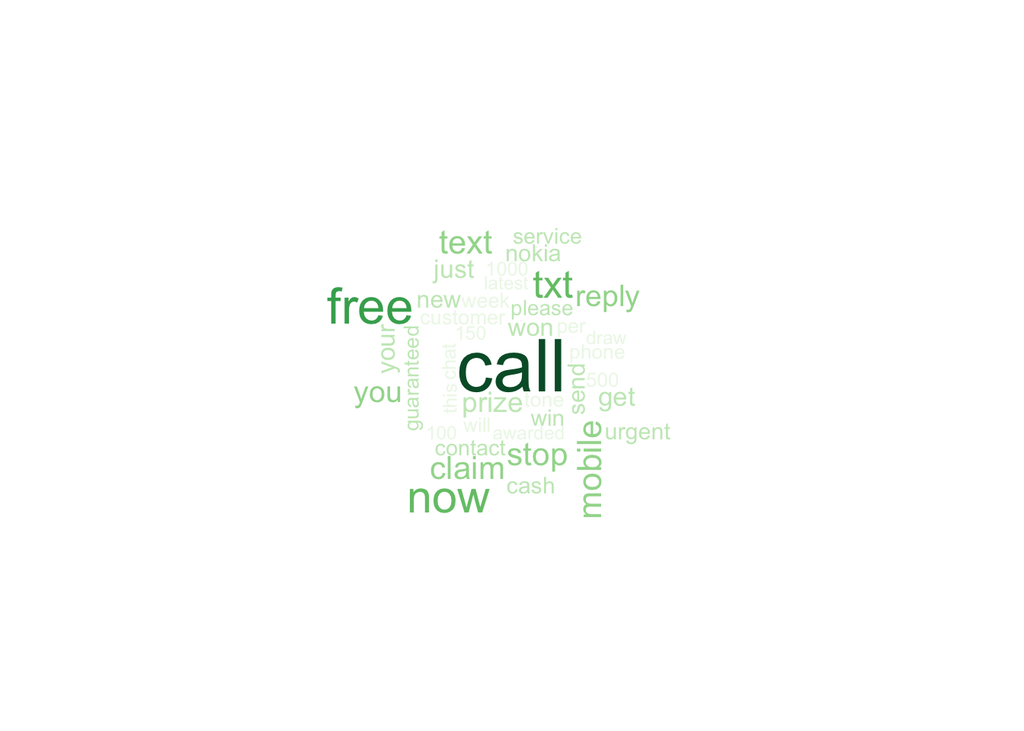

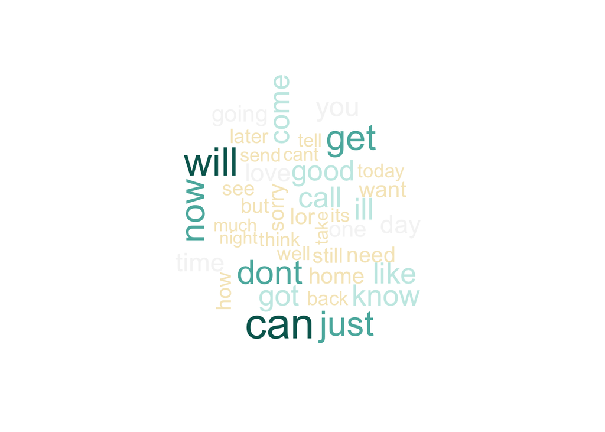

The stark differences in the resulting wordclouds suggest that the Naive Bayes model will have some strong key words to differentiate between the classes.

### 3.2.5 Data preparation - creating indicator features for frequent words

The final step in the data preparation process is to transform the sparse matrix into a data structure that can be used to train a Naive Bayes classifier. With over 6500 features (a feature for every word that appears in at least one SMS message), it’s unlikely that all of these are useful for classification. To reduce the number of features, eliminate any word that appears in less than five SMS messages. The *findFreqTerms()* method is used for this purpose, as shown here, to filter out words that appear in at least 5 SMS messages:

```r
sms_freq_words <- findFreqTerms(sms_dtm_train, 5)
str(sms_freq_words)
```

```
##  chr [1:1136] "abiola" "abl" "abt" "accept" "access" "account" ...
```

This vector can be used to filter the training and test datasets more finely to include only terms of a desired frequency:

```r
sms_dtm_freq_train <- sms_dtm_train[ , sms_freq_words]
sms_dtm_freq_test <- sms_dtm_test[, sms_freq_words]
```

The Naive Bayes classifier is typically trained on data with categorical features. This poses a problem, since the cells in the sparse matrix are numeric and measure the number of times a word appears in a message (document). To change the values to categorical variables that simply indicates *yes* or *no* depending on whether the word appears at all, the following code will convert counts to *Yes/No* strings:

```
convert_counts <- function(x) {
  x <- ifelse(x > 0, 1, 0)
  x <- factor(x, levels = c(0, 1), labels = c("No", "Yes"))
}
```

To ‘apply’ this, use the following code, where the **MARGIN** value specifies that the operation should be applied to the columns of the source dataset:

```r
sms_train <- apply(sms_dtm_freq_train, MARGIN = 2, convert_counts)
sms_test  <- apply(sms_dtm_freq_test, MARGIN = 2, convert_counts)
```

The result will be two character type matrices, each with cells indicating “Yes” or “No” for whether the word represented by the column appears at any point in the message represented by the row.

## 3.3 Step 3 - training a model on the data

Now that the raw SMS messages have been transformed into a format that can be represented by a statistical model, the Naive Bayes algorithm can be applied - it will used the presence or absence of words to estimate the probability that a given SMS message is spam. The Naive Bayes implementation in the `e1071` package will be used.

Unlike the k-NN algorithm, the Naive Bayes learner is trained and used for classification in separate stages.

**Building the classifier**

```
  m <- naiveBayes(train, class, laplace = 0)
```

where:

- *train* is a data frame or matrix containing training data
- *class* is a factor vector with the class for each row in the training data
- *laplace* is a number to control the Laplace estimator (0 by default)

This function will return a Naive Bayes model object that can be used to make predictions.

**Making Predictions**

```
p <- predict(m, test, type = "class")
```

where:

- *m* is a model trained by the `naiveBayes()` function
- *test* is a data frame or matrix containing test data with the same features as the training data used to build the classifier
- *type* is either “class” or “raw” and specifies whether the predictions should be the most likely class value or the raw predicted probabilities

The function will return a vector of predicted class values or raw predicted probabilities depending upon the value of the **type** parameter.

To build the model on the training dataset already constructed:

```r
sms_classifier <- naiveBayes(sms_train, sms_train_labels)
```

## 3.4 Step 4 - evaluating model performance

To evaluate the SMS classifier, the predictions need to be tested on unseen messages in the test data. The *predict()* function will use the classifier and test datasets created earlier and the predicted values will be compared to the labels associated with the test dataset.

```r
sms_test_pred <- predict(sms_classifier, sms_test)
```

To compare the predictions to the true values, we’ll use the `CrossTable()` function, using some additional parameters to make the output easier to read:

```r
CrossTable(sms_test_pred,
           sms_test_labels,
           prop.chisq = FALSE,
           prop.t = FALSE,
           dnn = c('predicted', 'actual'))
```

```
##
##
##    Cell Contents
## |-------------------------|
## |                       N |
## |           N / Row Total |
## |           N / Col Total |
## |-------------------------|
##
##
## Total Observations in Table:  1390
##
##
##              | actual
##    predicted |       ham |      spam | Row Total |
## -------------|-----------|-----------|-----------|
##          ham |      1201 |        30 |      1231 |
##              |     0.976 |     0.024 |     0.886 |
##              |     0.995 |     0.164 |           |
## -------------|-----------|-----------|-----------|
##         spam |         6 |       153 |       159 |
##              |     0.038 |     0.962 |     0.114 |
##              |     0.005 |     0.836 |           |
## -------------|-----------|-----------|-----------|
## Column Total |      1207 |       183 |      1390 |
##              |     0.868 |     0.132 |           |
## -------------|-----------|-----------|-----------|
##
##
```

Looking at the table, a total of only 2.6% of the 1,390 SMS messages were incorrectly classified (6 + 30 = 36). Among the errors were 6 out of 1207 ham messages that were misidentified as spam, and 30 of the 183 spam messages were incorrectly labeled as ham. On the other hand, the six legitimate messages that were incorrectly classified as spam could cause significant problems if, because of the filter, a person missed an important text messages. As always, the question is: Can the model be tweaked to improve performance and accuracy?

## 3.5 Step 5 - improving model performance

Since in the original build of the model the Laplace estimator was set to 0, it allowed words that appeared in zero spam or zero ham messages to have an indisputable say in the classification process. Can the model be improved by setting the Laplace estimator to 1? The previous steps are re-run, but this time with a parametric adjustment:

```r
sms_classifier2 <- naiveBayes(sms_train, sms_train_labels, laplace = 1)
sms_test_pred2 <- predict(sms_classifier2, sms_test)
CrossTable(sms_test_pred2,
           sms_test_labels,
           prop.chisq = FALSE,
           prop.t = FALSE,
           prop.r = FALSE,
           dnn = c('predicted', 'actual'))
```

```
##
##
##    Cell Contents
## |-------------------------|
## |                       N |
## |           N / Col Total |
## |-------------------------|
##
##
## Total Observations in Table:  1390
##
##
##              | actual
##    predicted |       ham |      spam | Row Total |
## -------------|-----------|-----------|-----------|
##          ham |      1202 |        28 |      1230 |
##              |     0.996 |     0.153 |           |
## -------------|-----------|-----------|-----------|
##         spam |         5 |       155 |       160 |
##              |     0.004 |     0.847 |           |
## -------------|-----------|-----------|-----------|
## Column Total |      1207 |       183 |      1390 |
##              |     0.868 |     0.132 |           |
## -------------|-----------|-----------|-----------|
##
##
```

# 4 Summary

This document discussed classification using Naive Bayes, so named because it is a simplified version of Bayes’ theorem that makes so-called “naive” assumptions about the independence of features. This algorithm constructs tables of probabilities that are used to estimate the likelihood that new examples belong to various classes.